# Case Study: Customer Segmentation &amp; Targeting

←Back to the bookChapter 123 · Customer Segmentation & Targeting

Chapter 123 · Case Study: Customer Segmentation & Targeting

Case Study: Customer Segmentation & Targeting

Combining unsupervised clustering with a supervised propensity model to run a smarter marketing campaign: segment customers by RFM and engagement, score each one's chance of responding, target by rank, and measure the lift and ROI over an untargeted campaign. Library-first with scikit-learn, and heavily visual.

Statistics, Data Science and AI: A Visual Handbook · John Fisher · 2026

# Customer Segmentation & Targeting: who to reach, and why

A marketing team has a budget to run one campaign. Blasting everyone wastes money on people who will never respond; the art is choosing **whom to contact**. This case study combines the two halves of machine learning: **unsupervised** clustering to discover natural customer **segments**, and a **supervised** propensity model to score each customer's chance of responding. Then we measure the payoff the way a business does, with a **lift/gains** chart and an **ROI** curve against an untargeted campaign. Library-first with `scikit-learn`.

```python
import numpy as np, pandas as pd, matplotlib.pyplot as plt
import seaborn as sns   # seaborn = high-level statistical plots (heatmaps, pairplots, count/bar plots)
from matplotlib.colors import ListedColormap
EM="#4338ca"; DEEP="#3730a3"; LIGHT="#c7d2fe"; INK="#1a2138"; GRID="#e6e9f2"; RED="#ef4444"; AMBER="#d97706"; GREEN="#059669"; BLUE="#2563eb"; PUR="#9333ea"; GREY="#94a3b8"; SLATE="#475569"; ORG="#4338ca"; CYAN="#0891b2"
plt.rcParams.update({"figure.facecolor":"white","axes.facecolor":"white","figure.dpi":110,"font.size":11,
   "axes.edgecolor":GRID,"axes.grid":True,"grid.color":GRID,"axes.axisbelow":True,"axes.spines.top":False,
   "axes.spines.right":False,"axes.titlesize":12,"axes.titleweight":"bold","legend.frameon":False})
sns.set_style("whitegrid")
BASE="https://raw.githubusercontent.com/johnfisher-ai/Statistics-Data-Science-AI-Visual-Book/main/data/"
```

```python
from sklearn.model_selection import train_test_split
from sklearn.pipeline import Pipeline
from sklearn.impute import SimpleImputer
from sklearn.preprocessing import StandardScaler
from sklearn.cluster import KMeans
from sklearn.decomposition import PCA
from sklearn.metrics import silhouette_score, roc_auc_score, average_precision_score
from sklearn.linear_model import LogisticRegression
import warnings; warnings.filterwarnings('ignore'); pd.set_option('display.max_columns', 40)
```

STEP 1 · DEFINE THE OBJECTIVE

Spend the campaign budget where it pays

Target the customers most worth reaching.

**The goal, in two parts.** First, *understand* the customer base by grouping it into a few meaningful **segments** (who are our customers?). Second, *act*: build a model that scores each customer's **propensity** to respond, so the campaign contacts the most promising people first. Success is not accuracy, it is **profit**, more responses per dollar spent than a blanket mailing would earn.

STEP 2 · COLLECT THE DATA

A customer table

One row per customer.

```python
try: df = pd.read_csv('../../data/marketing_campaign.csv')
except FileNotFoundError: df = pd.read_csv(BASE + 'marketing_campaign.csv')
print('raw shape:', df.shape); df.head(3)
```

```
raw shape: (4230, 9)
```

|  | customer_id | recency_days | frequency | monetary | tenure_months | email_opens_90d | prior_responses | age | responded |
| --- | --- | --- | --- | --- | --- | --- | --- | --- | --- |
| 0 | C40765 | 18 | 15 | 1865.0 | 78 | 38 | 2 | 60.0 | 0 |
| 1 | C40862 | 31 | 9 | 2324.0 | 59 | 33 | 3 | 42.0 | 1 |
| 2 | C40749 | 15 | 28 | 385.0 | 67 | 25 | 4 | 45.0 | 1 |

**Classic RFM plus engagement.** Each customer has **Recency** (days since last purchase), **Frequency**, and **Monetary** value, the RFM trio marketers live by, plus tenure, email opens, prior campaign responses, and age. The `responded` column records whether they responded to the *last* campaign, which the propensity model will learn to predict.

STEP 3 · INSPECT

Size, response rate, gaps

How many customers, how many respond?

```python
print('customers:', len(df), '| overall response rate: %.1f%%' % (df.responded.mean()*100))
print('missing:', dict(df[['monetary','age']].isna().sum()))
print('duplicate ids:', df.customer_id.duplicated().sum())
```

```
customers: 4230 | overall response rate: 20.9%
missing: {'monetary': np.int64(41), 'age': np.int64(25)}
duplicate ids: 30
```

**A moderately rare, valuable event.** About **21%** of customers responded last time. That is the untargeted baseline to beat: if we contact a random person, roughly one in five responds. The whole point of targeting is to do far better than that per contact. A few missing values and duplicates need a quick clean.

STEP 4 · CLEAN

Tidy up

Dedupe; leave gaps for the pipelines.

```python
df = df.drop_duplicates('customer_id').reset_index(drop=True)
feats = ['recency_days','frequency','monetary','tenure_months','email_opens_90d','prior_responses','age']
print('after dedupe:', df.shape, '| response rate still %.1f%%' % (df.responded.mean()*100))
```

```
after dedupe: (4200, 9) | response rate still 20.9%
```

**Minimal, deliberate cleaning.** We remove duplicate customers and otherwise leave the missing `monetary` and `age` values in place, both the clustering and the model will impute them inside their pipelines, on training data only. After cleaning, **4,200 customers** remain.

STEP 5 · VISUALIZE

The RFM landscape

Customers spread out along value and recency.

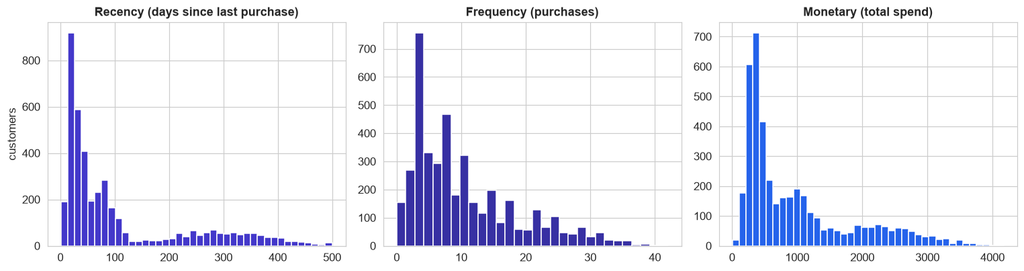

```
response rate by email engagement:
opens_bucket
(-1, 2]     0.013
(2, 10]     0.075
(10, 25]    0.195
(25, 60]    0.671
```

```python
fig, ax = plt.subplots(1, 3, figsize=(14,3.8))
ax[0].hist(df.recency_days, bins=40, color=EM); ax[0].set(title='Recency (days since last purchase)', ylabel='customers')
ax[1].hist(df.frequency, bins=30, color=DEEP); ax[1].set(title='Frequency (purchases)')
ax[2].hist(df.monetary.dropna(), bins=40, color=BLUE); ax[2].set(title='Monetary (total spend)')
plt.tight_layout(); plt.show()
print('response rate by email engagement:')
print(df.assign(opens_bucket=pd.cut(df.email_opens_90d,[-1,2,10,25,60])).groupby('opens_bucket').responded.mean().round(3).to_string())
```

**Heterogeneous customers.** The distributions are skewed, most customers are low-frequency and low-spend, with a long tail of valuable ones. And response is far from uniform: it climbs steeply with email engagement. That heterogeneity is exactly why a single average is useless and why we segment first.

STEP 6 · SEGMENT (UNSUPERVISED)

Discover the customer types

Cluster on RFM + engagement, then name the groups.

```
silhouette by k: {2: 0.423, 3: 0.405, 4: 0.402, 5: 0.378, 6: 0.324}
                     n  recency  frequency  monetary  opens  response_rate
segment_name
Champions          960     18.2       22.2    2314.7   30.4            0.6
Lapsed / at-risk  1043    298.9        3.0     418.8    2.0            0.0
Loyal regulars    1143     77.0       11.1     970.2   13.5            0.1
New browsers      1054     35.8        6.2     309.0   10.0            0.1
```

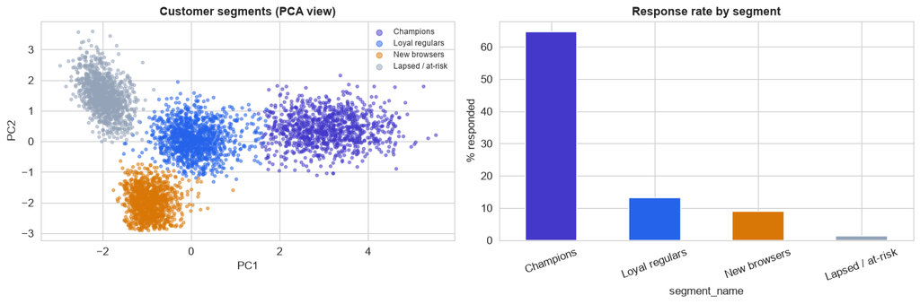

```python
seg_pipe = Pipeline([('impute', SimpleImputer(strategy='median')), ('scale', StandardScaler())])
Xs = seg_pipe.fit_transform(df[feats])
sil = {k: silhouette_score(Xs, KMeans(n_clusters=k, n_init=10, random_state=0).fit_predict(Xs)) for k in range(2,7)}
print('silhouette by k:', {k: round(v,3) for k,v in sil.items()})
km = KMeans(n_clusters=4, n_init=10, random_state=0).fit(Xs); df['segment'] = km.labels_
# name each cluster from its profile (labels are unsupervised, so name by behavior)
prof = df.groupby('segment')[feats].mean()
names = {prof.monetary.idxmax(): 'Champions', prof.recency_days.idxmax(): 'Lapsed / at-risk'}
rest = [s for s in prof.index if s not in names]
rs = prof.loc[rest].frequency.sort_values(ascending=False)
names[rs.index[0]] = 'Loyal regulars'; names[rs.index[1]] = 'New browsers'
df['segment_name'] = df.segment.map(names)
summary = df.groupby('segment_name').agg(n=('customer_id','size'), recency=('recency_days','mean'), frequency=('frequency','mean'), monetary=('monetary','mean'), opens=('email_opens_90d','mean'), response_rate=('responded','mean')).round(1)
print(summary.to_string())
fig, ax = plt.subplots(1, 2, figsize=(13,4.4))
P = PCA(n_components=2).fit_transform(Xs)
for name,c in zip(['Champions','Loyal regulars','New browsers','Lapsed / at-risk'], [EM,BLUE,AMBER,GREY]):
    m = df.segment_name==name; ax[0].scatter(P[m,0], P[m,1], s=8, c=c, alpha=0.5, label=name)
ax[0].set(title='Customer segments (PCA view)', xlabel='PC1', ylabel='PC2'); ax[0].legend(markerscale=2, fontsize=8)
(df.groupby('segment_name').responded.mean()*100).reindex(['Champions','Loyal regulars','New browsers','Lapsed / at-risk']).plot.bar(ax=ax[1], color=[EM,BLUE,AMBER,GREY])
ax[1].set(title='Response rate by segment', ylabel='% responded'); ax[1].tick_params(axis='x', rotation=20)
plt.tight_layout(); plt.show()
```

**Four customer types, discovered without labels.** K-means on the standardized RFM and engagement features finds four clear groups, and profiling their averages lets us *name* them: **Champions** (recent, frequent, high-spend, engaged), **Loyal regulars**, **New browsers**, and **Lapsed / at-risk**. The silhouette score gently favors fewer clusters, but four is the actionable choice, each maps to a distinct, nameable customer, a reminder that **k is often a business decision, not just a statistical one**. Crucially, response rate swings enormously across segments, from about **1% for the lapsed group to 65% for Champions**, so *who* a customer is already says a lot about whether they will respond.

STEP 7 · SPLIT

Train the propensity model honestly

Hold out customers for an unbiased score.

```python
X = df[feats]; y = df['responded']
X_train, X_test, y_train, y_test = train_test_split(X, y, test_size=0.30, random_state=0, stratify=y)
print('train:', len(X_train), 'customers |', y_train.sum(), 'responders')
print('test :', len(X_test), 'customers |', y_test.sum(), 'responders (used to judge the campaign)')
```

```
train: 2940 customers | 615 responders
test : 1260 customers | 264 responders (used to judge the campaign)
```

**Segments describe; the propensity model decides.** Segmentation grouped everyone; now we build a **supervised** model that scores each customer's probability of responding, which is what actually drives the contact list. We hold out 30% of customers to measure the targeting honestly, exactly as in the earlier case studies.

STEP 8 · PROPENSITY MODEL (SUPERVISED)

Score every customer's chance to respond

A calibrated probability per person.

```
propensity model ROC-AUC: 0.866 | PR-AUC: 0.661
```

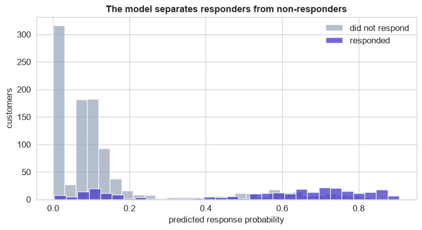

```python
model = Pipeline([('impute', SimpleImputer(strategy='median')), ('scale', StandardScaler()), ('clf', LogisticRegression(max_iter=2000))]).fit(X_train, y_train)
prob = model.predict_proba(X_test)[:,1]
print('propensity model ROC-AUC: %.3f | PR-AUC: %.3f' % (roc_auc_score(y_test, prob), average_precision_score(y_test, prob)))
fig, ax = plt.subplots(figsize=(7.6,4.2))
ax.hist(prob[y_test==0], bins=30, color=GREY, alpha=0.7, label='did not respond')
ax.hist(prob[y_test==1], bins=30, color=EM, alpha=0.75, label='responded')
ax.set(title='The model separates responders from non-responders', xlabel='predicted response probability', ylabel='customers'); ax.legend()
plt.tight_layout(); plt.show()
```

**A good ranker.** The logistic propensity model earns a **ROC-AUC around 0.87**, it reliably scores responders higher than non-responders. The histogram shows the separation: responders (indigo) pile up at higher predicted probabilities. We do not need a perfect classifier here, only a good *ranking*, because targeting is about ordering customers from most to least promising.

STEP 9 · TARGET (GAINS & LIFT)

The payoff of targeting

Rank by propensity; reach the best first.

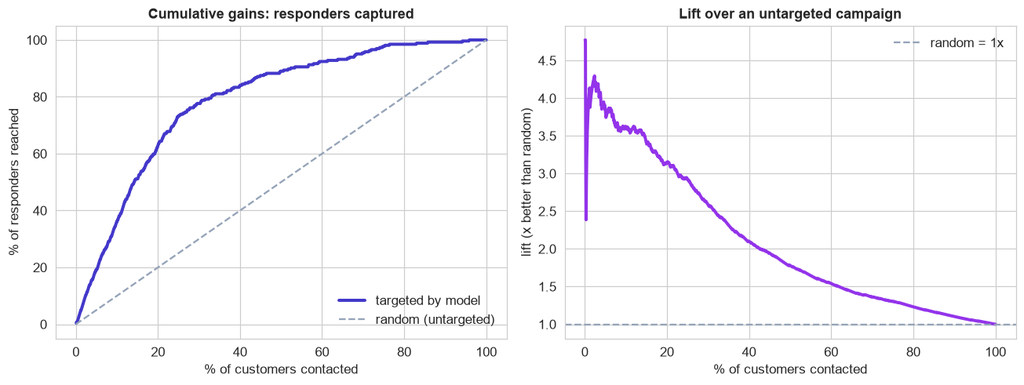

```
contact top 10% -> reach 36% of responders (3.6x lift)
contact top 20% -> reach 63% of responders (3.1x lift)
contact top 30% -> reach 78% of responders (2.6x lift)
```

```python
order = np.argsort(-prob)
gains = np.cumsum(y_test.values[order]) / y_test.sum()
pct = np.arange(1, len(order)+1) / len(order)
fig, ax = plt.subplots(1, 2, figsize=(12,4.6))
ax[0].plot(pct*100, gains*100, color=EM, lw=2.6, label='targeted by model')
ax[0].plot([0,100],[0,100], '--', color=GREY, label='random (untargeted)')
ax[0].set(title='Cumulative gains: responders captured', xlabel='% of customers contacted', ylabel='% of responders reached'); ax[0].legend(loc='lower right')
lift = gains / pct
ax[1].plot(pct*100, lift, color=PUR, lw=2.6); ax[1].axhline(1, color=GREY, ls='--', label='random = 1x')
ax[1].set(title='Lift over an untargeted campaign', xlabel='% of customers contacted', ylabel='lift (x better than random)'); ax[1].legend()
plt.tight_layout(); plt.show()
for f in [0.1, 0.2, 0.3]:
    k = int(f*len(order)); print('contact top %2d%% -> reach %2.0f%% of responders (%.1fx lift)' % (f*100, gains[k-1]*100, lift[k-1]))
```

**This is why targeting works.** Rank customers by propensity and contact the top of the list first. The **cumulative gains** curve bows far above the diagonal: contacting the **top 20%** of customers reaches about **63% of all responders**, more than three times what a random 20% would reach. The **lift** curve says the same thing directly, the best-scored customers are about **3x** likelier to respond than a random pick. The campaign captures most of the value while contacting a fraction of the list.

STEP 10 · ROI

How many should we actually contact?

Put dollars on it: cost per contact, value per response.

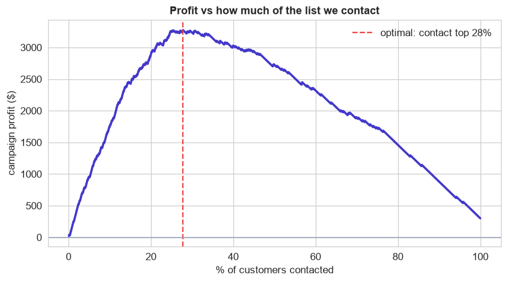

```
optimal: contact top 28% -> profit $3275
contact everyone     -> profit $300
do nothing           -> profit $0
```

```python
CONTACT_COST = 5     # cost to reach one customer
RESPONSE_VALUE = 25  # profit from one response
n = len(order); resp_sorted = y_test.values[order]
profit = np.cumsum(resp_sorted)*RESPONSE_VALUE - np.arange(1, n+1)*CONTACT_COST
best_k = int(np.argmax(profit)) + 1
fig, ax = plt.subplots(figsize=(7.8,4.4))
ax.plot(pct*100, profit, color=EM, lw=2.4)
ax.axvline(best_k/n*100, color=RED, ls='--', label=f'optimal: contact top {best_k/n*100:.0f}%')
ax.axhline(0, color=GREY, lw=1)
ax.set(title='Profit vs how much of the list we contact', xlabel='% of customers contacted', ylabel='campaign profit ($)'); ax.legend()
plt.tight_layout(); plt.show()
everyone = y_test.sum()*RESPONSE_VALUE - n*CONTACT_COST
print('optimal: contact top %.0f%% -> profit $%d' % (best_k/n*100, profit[best_k-1]))
print('contact everyone     -> profit $%d' % everyone)
print('do nothing           -> profit $0')
```

STEP 11 · INTERPRET

What drives response, and where the value sits

The two halves meet.

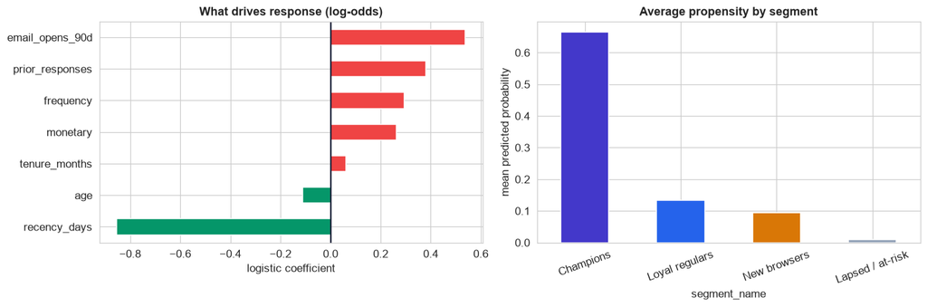

```
top response drivers: email_opens_90d, prior_responses, frequency
```

```python
coefs = pd.Series(model.named_steps['clf'].coef_[0], index=feats).sort_values()
fig, ax = plt.subplots(1, 2, figsize=(13,4.4))
coefs.plot.barh(ax=ax[0], color=[RED if c>0 else GREEN for c in coefs.values]); ax[0].axvline(0, color=INK)
ax[0].set(title='What drives response (log-odds)', xlabel='logistic coefficient')
df_test = X_test.copy(); df_test['prob'] = prob; df_test['segment_name'] = df.loc[X_test.index, 'segment_name']
(df_test.groupby('segment_name').prob.mean()).reindex(['Champions','Loyal regulars','New browsers','Lapsed / at-risk']).plot.bar(ax=ax[1], color=[EM,BLUE,AMBER,GREY])
ax[1].set(title='Average propensity by segment', ylabel='mean predicted probability'); ax[1].tick_params(axis='x', rotation=20)
plt.tight_layout(); plt.show()
print('top response drivers:', ', '.join(coefs.tail(3).index[::-1]))
```

**Segments and scores tell one story.** The propensity model leans on **email engagement**, **prior responses**, **frequency**, and **spend** (all raising response odds), and on **recency** (recent buyers respond, dormant ones do not), the same traits that define the Champions segment. Averaging the propensity score within each segment closes the loop: **Champions** carry by far the highest average propensity, **Lapsed** the lowest. The unsupervised segments and the supervised scores agree, and together they tell the marketer not just *who* to contact but *why*.

STEP 12 · DEPLOY ON NEW DATA

Score a new customer, decide the action

Segment, propensity, and a contact decision.

```python
import joblib
joblib.dump(model, 'propensity_model.joblib'); joblib.dump(km, 'segment_model.joblib')
clf = joblib.load('propensity_model.joblib'); segmenter = joblib.load('segment_model.joblib')
TARGET_THRESHOLD = CONTACT_COST / RESPONSE_VALUE     # contact only if expected value is positive
new_customers = pd.DataFrame([
  {'recency_days':15,'frequency':24,'monetary':2600,'tenure_months':64,'email_opens_90d':34,'prior_responses':4,'age':41},  # looks like a Champion
  {'recency_days':310,'frequency':2,'monetary':300,'tenure_months':50,'email_opens_90d':1,'prior_responses':0,'age':55}])   # looks lapsed
seg_labels = segmenter.predict(seg_pipe.transform(new_customers))
for i, row in new_customers.iterrows():
    p = clf.predict_proba(new_customers.iloc[[i]])[0,1]
    action = 'CONTACT (expected profit positive)' if p >= TARGET_THRESHOLD else 'skip (not worth the cost)'
    print(f'customer {i+1}: segment "{names[seg_labels[i]]}", response probability {p:.0%}  ->  {action}')
print('\nin production: score the whole base nightly, contact everyone above the value threshold,')
print('run a holdout control group to measure real incremental lift, and refresh segments as behavior shifts.')
```

```
customer 1: segment "Champions", response probability 79%  ->  CONTACT (expected profit positive)
customer 2: segment "Lapsed / at-risk", response probability 1%  ->  skip (not worth the cost)

in production: score the whole base nightly, contact everyone above the value threshold,
run a holdout control group to measure real incremental lift, and refresh segments as behavior shifts.
```

**From analysis to a campaign list.** The saved pipelines turn a new customer record into an action in one pass: assign a **segment**, compute a **response probability**, and contact only if the expected value (probability times response value) beats the contact cost. The Champion-like customer is an obvious contact; the lapsed one is not worth the postage. In production the base is scored regularly, and, importantly, a **holdout control group** left uncontacted lets the team measure the campaign's *incremental* lift, the true test of whether targeting paid off. Chapter 126 covers running this in production.

## Segmentation and targeting, in one view

**Unsupervised learning tells you who your customers are; supervised learning tells you which ones to act on. Targeting is where they meet.**

Statistics, Data Science and AI: A Visual Handbook · © 2026 John Fisher

←Back to the bookChapter 123 · Customer Segmentation & Targeting